# Diagonal Case

## 5.3 The output from the fit

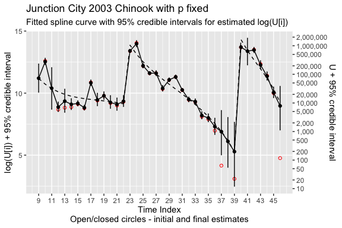

Fitted spline curve with fixed p’s

```r
demo2.fit$plots$fit.plot
```

The jump in the spline when hatchery fish are released is evident.

The distribution of the posterior sample for the total number unmarked and total abundance is available as before:

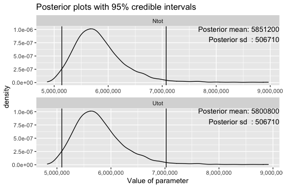

Distribution of posterior samples

```r
demo2.fit$plots$post.UNtot.plot
```

A plot of the $logit(P)$ is

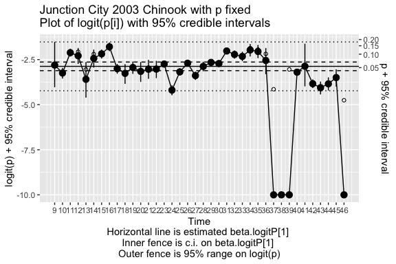

Estimates of logit(p)

```r
demo2.fit$plots$logitP.plot
```

Notice how the fixed values at $-10$ (on the logit scale) occur.

A summary of the posterior for each parameter is also available. In particular, here are the summary statistics on the posterior sample for the total number unmarked and total abundance:

```r
demo2.fit$summary[ row.names(demo2.fit$summary) %in% c("Ntot","Utot"),]
```

```
#>         mean       sd    2.5%     25%     50%     75%   97.5%     Rhat n.eff
#> Ntot 5851224 506714.6 5140894 5516261 5769217 6062302 7073362 1.007011   300
#> Utot 5800759 506714.6 5090429 5465796 5718752 6011837 7022897 1.007020   300
```

The estimated total abundance from $BTSPAS$ is 5,851,224 (SD 506,715 ) fish.

# 6 Using covariates to model the p’s

*BTSPAS* also allows you to model the p’s with additional covariates, such a temperature, stream flow, etc. It is not possible to use covariates to model the total number of unmarked fish.

## 6.1 Reading in the data

Here is an example of some raw data that includes the covariate $log(flow)$:

```r
demo3.data.csv <- textConnection(
'jweek, n1, m2,    u2, logflow
 9,    0,    0,  4135, 6.617212
10, 1465,   51, 10452, 6.51217
11, 1106,  121,  2199, 7.193686
12,  229,   25,   655, 6.960754
13,   20,    0,   308, 7.008376
14,  177,   17,   719, 6.761573
15,  702,   74,   973, 6.905753
16,  633,   94,   972, 7.062314
17, 1370,   62,  2386, 7.600188
18,  283,   10,   469, 8.246509
19,  647,   32,   897, 8.110298
20,  276,   11,   426, 8.035001
21,  277,   13,   407, 7.859965
22,  333,   15,   526, 7.774255
23, 3981,  242, 39969, 7.709116
24, 3988,   55, 17580, 7.653766
25, 2889,  115,  7928, 7.622105
26, 3119,  198,  6918, 7.593734
27, 2478,   80,  3578, 7.585063
28, 1292,   71,  1713, 7.291072
29, 2326,  153,  4212, 6.55556
30, 2528,  156,  5037, 6.227665
31, 2338,  275,  3315, 6.278789
32, 1012,  101,  1300, 6.273685
33,  729,   66,   989, 6.241111
34,  333,   44,   444, 6.687999
35,  269,   33,   339, 7.222566
36,   77,    7,   107, 7.097194
37,   62,    9,    79, 6.949993
38,   26,    3,    41, 6.168714
39,   20,    1,    23, 6.113682
40, 4757,  188, 35118, 6.126557
41, 2876,    8, 34534, 6.167217
42, 3989,   81, 14960, 5.862413
43, 1755,   27,  3643, 5.696614
44, 1527,   30,  1811, 5.763847
45,  485,   14,   679, 5.987528
46,  115,    4,   154, 5.912344')

demo3.data <- read.csv(demo3.data.csv, header=TRUE, as.is=TRUE, strip.white=TRUE)

print(demo3.data)
```

```
#>    jweek   n1  m2    u2  logflow
#> 1      9    0   0  4135 6.617212
#> 2     10 1465  51 10452 6.512170
#> 3     11 1106 121  2199 7.193686
#> 4     12  229  25   655 6.960754
#> 5     13   20   0   308 7.008376
#> 6     14  177  17   719 6.761573
#> 7     15  702  74   973 6.905753
#> 8     16  633  94   972 7.062314
#> 9     17 1370  62  2386 7.600188
#> 10    18  283  10   469 8.246509
#> 11    19  647  32   897 8.110298
#> 12    20  276  11   426 8.035001
#> 13    21  277  13   407 7.859965
#> 14    22  333  15   526 7.774255
```

[output cut: 24 more lines]

A preliminary plot of the empirical logit (excluding those weeks when the trap was not running) shows an approximate quadratic fit to $log(flow)$, but the uncertainty in each week is enormous!

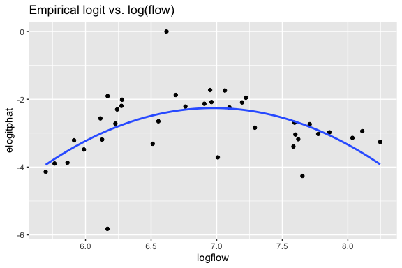